# AllElectronics Customer Database - Clasificación naive bayes

- **Víctor Bucheli Guerrero**
- **Universidad del Valle**
- **Mayo 31 / 2018**

# AllElectronics Customer Database

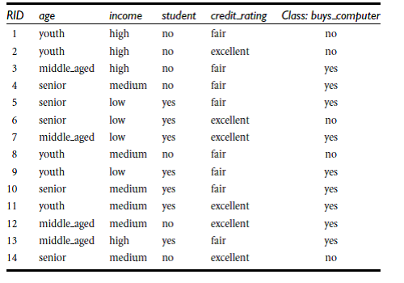

**Información relevante al dataset:**

Este conjunto de datos proviene de una empresa que vende productos electrónicos, para este conjunto de datos en específico se tienen los siguientes atributos:

- **Age(Edad)**: Representa la edad de un cliente, como la edad es un tipo de dato númerico se convierte a categórico clasificando la edad en youth(joven) menor o igual a 30, middle_aged(mediana edad) entre 31 y 40 y senior(mayor) mayor a 40.
- **Income(ingresos)**: Representa los ingresos de un cliente, como los ingresos son de tipo númerico se convierte a categórico clasificando los ingresos en low(bajo), medium(medio) y high(alto), los límites para clasificar son desconocidos.
- **Student(estudiante)**: Repesenta si el cliente es estudiante o no, sólo tiene dos valores sí y no.
- **Credit_rating(clasificación crediticia)**: Representa que tan buen deudor es el cliente, se clasifica en fair(razonable) y excellent(excelente).
- **Buys_computer(Compra computador)**: Representa si el cliente compró un computador o no. Es la clase.

## Carga de datos

```r
#Cargamos el dataset
allelectronics.dataset <- read.csv("allelectronics.csv", header = TRUE)# El archivo csv ya tiene los nombres de las columnas
#volvemos categorico la columna "buys_computer"
allelectronics.dataset[, "buys_computer"] <-as.factor(allelectronics.dataset[, "buys_computer"])
```

## Partir los datos en el conjunto de entrenamiento y de pruebas

El conjunto de entrenamiento es allelectronics.dataset, el conjunto de pruebas será el ejemplo que se vio en las presentaciones.

```r
#Especficamos los valores de prueba
age <- c("youth")
income <- c("medium")
student <- c("yes")
credit_rating <- c("fair")
conjunto_entrenamiento <- as.data.frame(allelectronics.dataset) #Conjunto de entrenamiento
#Creamos el dataset para las pruebas
conjunto_prueba <- data.frame(age,income,student,credit_rating) #Conjunto de Prueba
#Transformamos las columnas del conjunto de prueba
conjunto_prueba[,"age"] <- as.character(conjunto_prueba[,"age"])
conjunto_prueba[,"income"] <- as.character(conjunto_prueba[,"income"])
conjunto_prueba[,"student"] <- as.character(conjunto_prueba[,"student"])
conjunto_prueba[,"credit_rating"] <- as.character(conjunto_prueba[,"credit_rating"])
```

## Entrenamiento

Vamos a calcular cada una de las probabilidades, vamos a ir por pasos:

1. Calcular las probabilidades previas de buys_computer (Etiqueta de clase)

```r
tprior <- table(conjunto_entrenamiento$buys_computer)
tprior #Cantidad
```

```
 no yes
  5   9
```

```r
tprior <- tprior/sum(tprior)
tprior #Probabilidad
```

```
       no       yes
0.3571429 0.6428571
```

2. Ahora calculamos las probabilidades condicionales P(X|C) donde X puede ser {Age,Income,Student,Credit_rating} y C es la clase (buys_computer)

   **Age**

```r
ageCounts <- table(conjunto_entrenamiento[,c("buys_computer", "age")])
ageCounts#Cantidad
```

```
             age
buys_computer middle_aged senior youth
          no            0      2     3
          yes           4      3     2
```

```r
ageCounts <- ageCounts/rowSums(ageCounts)
ageCounts#Probabilidad
```

```
             age
buys_computer middle_aged    senior     youth
          no    0.0000000 0.4000000 0.6000000
          yes   0.4444444 0.3333333 0.2222222
```

[output not shown]

```r
incomeCounts <- table(conjunto_entrenamiento[,c("buys_computer", "income")])
incomeCounts#Cantidad
```

```
             income
buys_computer high low medium
          no     2   1      2
          yes    2   3      4
```

```r
incomeCounts <- incomeCounts/rowSums(incomeCounts)
incomeCounts#Probabilidad
```

```
             income
buys_computer      high       low    medium
          no  0.4000000 0.2000000 0.4000000
          yes 0.2222222 0.3333333 0.4444444
```

[output not shown]

```r
studentCounts <- table(conjunto_entrenamiento[,c("buys_computer", "student")])
studentCounts#Cantidad
```

```
             student
buys_computer no yes
          no   4   1
          yes  3   6
```

```r
studentCounts <- studentCounts/rowSums(studentCounts)
studentCounts#Probabilidad
```

```
             student
buys_computer        no       yes
          no  0.8000000 0.2000000
          yes 0.3333333 0.6666667
```

[output not shown]

```r
creditCounts <- table(conjunto_entrenamiento[,c("buys_computer", "credit_rating")])
creditCounts#Cantidad
```

```
             credit_rating
buys_computer excellent fair
          no          3    2
          yes         3    6
```

```r
creditCounts <- creditCounts/rowSums(creditCounts)
creditCounts#Probabilidad
```

```
             credit_rating
buys_computer excellent      fair
          no  0.6000000 0.4000000
          yes 0.3333333 0.6666667
```

3. Ahora, teniendo nuestro conjunto de prueba como **X** = {age = youth, income = medium, student = yes, credit_rating = fair} la teoría nos dice que la probabilidad P(C|X) es:

   Donde C<sub>i</sub> representa las etiquetas de clase, para este caso sí y no (yes, no) y X<sub>i</sub> repesenta cada uno de los atributos de X. Calculamos nuestra probabilidad con la evidencia X.

```r
#Notemos que ahora calculamos la probabilidad con el conjunto de prueba, es decir ya estamos probando nuestro modelo
prob_yes <- ageCounts["yes",conjunto_prueba[,c("age")]] *
            incomeCounts["yes",conjunto_prueba[,c("income")]] *
            studentCounts["yes",conjunto_prueba[,c("student")]] *
            creditCounts["yes",conjunto_prueba[,c("credit_rating")]] *
            tprior["yes"]
prob_yes
```

```
       yes
0.02821869
```

```r
prob_no <- ageCounts["no",conjunto_prueba[,c("age")]] *
           incomeCounts["no",conjunto_prueba[,c("income")]] *
           studentCounts["no",conjunto_prueba[,c("student")]] *
           creditCounts["no",conjunto_prueba[,c("credit_rating")]] *
           tprior["no"]
prob_no
```

```
         no
0.006857143
```

```r
max(prob_yes,prob_no)
```

```
[1] 0.02821869
```

Notemos que los resultados concuerdan con los mostrados en la presentación, para el conjunto de prueba el resultado sería yes. Que sí compra computador un cliente con esas características.

Utilizaremos ahora el algoritmo naiveBayes que provee R.

Para utilizar el algoritmo Naive Bayes utilizamos la función predeterminada que viene en la librería e1071. Para este caso concreto vamos a utilizar la función naiveBayes ingresando la formula y el conjunto del cual se entrenará el modelo. La formula viene dada de la siguiente forma

### *C<sub>1</sub> ~ X<sub>1</sub> + X<sub>2</sub> + … + X<sub>n</sub>*

Donde *C<sub>1</sub>* es la clase y *X<sub>i</sub>* son los atributos que nos ayudarán a determinar la clase.

```r
#install.packages("e1071", dep = TRUE)
library(e1071)
formula <- buys_computer ~ age + income + student + credit_rating
modelo <- naiveBayes(formula, data = conjunto_entrenamiento)
```

Una vez hemos creado el modelo podemos observar algo importante, las probabilidades que nosotros calculamos con anterioridad ya están calculadas en el modelo

```r
modelo
```

```
Naive Bayes Classifier for Discrete Predictors

Call:
naiveBayes.default(x = X, y = Y, laplace = laplace)

A-priori probabilities:
Y
       no       yes
0.3571429 0.6428571

Conditional probabilities:
     age
Y     middle_aged    senior     youth
  no    0.0000000 0.4000000 0.6000000
  yes   0.4444444 0.3333333 0.2222222

     income
Y          high       low    medium
  no  0.4000000 0.2000000 0.4000000
  yes 0.2222222 0.3333333 0.4444444

     student
Y            no       yes
  no  0.8000000 0.2000000
  yes 0.3333333 0.6666667

     credit_rating
Y     excellent      fair
  no  0.6000000 0.4000000
  yes 0.3333333 0.6666667
```

```r
prediccion <- suppressWarnings(predict(modelo,conjunto_prueba))
prediccion
```

```
[1] yes
Levels: no yes
```